# Visualize big correlation matrix

In this post we are going to visualize correlation matrix in which most of the correlations are small while only a few individual correlations have high values. In reality, this highlights significant correlations between entities.

In following example, we simulate one such matrix. In this matrix, we only simulate random values for the upper triangular matrix.

```r
set.seed(123)
mat = matrix(nrow = 100, ncol = 100)
diag(mat) = 0
mat[lower.tri(mat)] = 0
mat[upper.tri(mat)] = rnorm(99*50, sd = 0.1)
ind = sample(99*50, 30)
mat[upper.tri(mat)][ind] = runif(30, min = -1, max = 1)
rownames(mat) = paste0("R", 1:100)
colnames(mat) = rownames(mat)
n = nrow(mat)
rn = rownames(mat)
```

In most cases, since there are so many, say, entities in the matrix, they are normally grouped and we also want to see correlations between groups.

Following simulates the groupings as a list.

```r
group_size = c(12, 8, 7, 16, 6, 2, 16, 13, 20)
gl = lapply(1:9, function(i) {
    rownames(mat)[sum(group_size[seq_len(i-1)]) + 1:group_size[i]]
})
names(gl) = paste0("G", 1:9)
gl[1:2]
```

```
## $G1
##  [1] "R1"  "R2"  "R3"  "R4"  "R5"  "R6"  "R7"  "R8"  "R9"  "R10" "R11"
## [12] "R12"
##
## $G2
## [1] "R13" "R14" "R15" "R16" "R17" "R18" "R19" "R20"
```

We convert `gl` to `gd` so that it is easy to know the groups given the names of the entity. We also generate the colors which correspond to the groups.

```r
gd = structure(rep(names(gl), times = sapply(gl, length)), names = unlist(gl))
group_color = structure(circlize::rand_color(9), names = names(gl))
n_group = length(gl)
```

The most straightforward way is to visualize the correlation matrix as a heamtap.

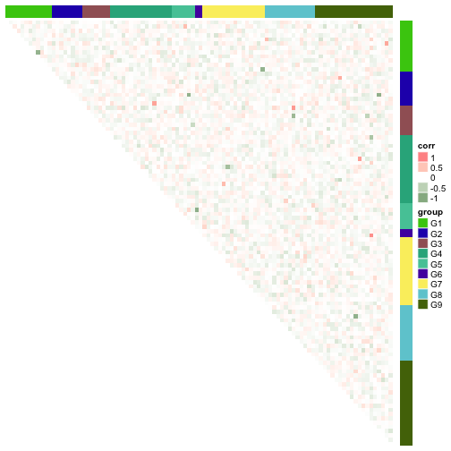

```r
library(ComplexHeatmap)
library(circlize)
col_fun = colorRamp2(c(-1, 0, 1), c("darkgreen", "white", "red"), transparency = 0.5)
Heatmap(mat, name = "corr", col = col_fun, cluster_rows = FALSE, cluster_columns = FALSE,
    show_row_names = FALSE, show_column_names = FALSE,
    top_annotation = HeatmapAnnotation(group = gd, col = list(group = group_color), show_legend = FALSE)) +
rowAnnotation(group = gd, col = list(group = group_color), width = unit(0.5, "cm"))
```

It is easy to find there are grids with deep colors which represent high correlations. However, there are several disadvantages. First, when there are many entities in the matrix, normally the row names/column names in the heatmap are turned off which makes it impossible to know where the correlation comes from. Second, it is not easy to correspond the significant grids to the groups neither. Third, when you have more than one correlation matrix to compare, actually comparison between matrix is difficult (e.g. a significant correlation between R10 and R20 in the first matrix while between R10 and R21 in the second matrix).

To partially solve these problems, next we visualize it by Chord diagram. In following circular plot, there are circular lines on the outside of the circle which represent groups and the highest correlations are drawn on the very top.

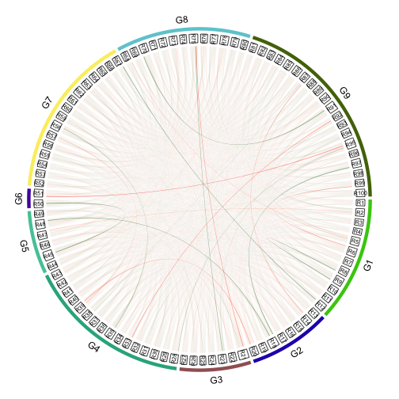

```r
chordDiagram(mat, col = col_fun(mat), grid.col = NA, grid.border = "black",
    annotationTrack = "grid", link.largest.ontop = TRUE,
    preAllocateTracks = list(
        list(track.height = 0.02)
    )
)

circos.trackPlotRegion(track.index = 2, panel.fun = function(x, y) {
    xlim = get.cell.meta.data("xlim")
    ylim = get.cell.meta.data("ylim")
    sector.index = get.cell.meta.data("sector.index")
    circos.text(mean(xlim), mean(ylim), sector.index, col = "black", cex = 0.6,
        facing = "clockwise", niceFacing = TRUE)
}, bg.border = NA)

for(nm in names(gl)) {
    r = gl[[nm]]
    highlight.sector(sector.index = r, track.index = 1, col = group_color[nm],
        text = nm, text.vjust = -1, niceFacing = TRUE)
}
```

```r
circos.clear()
```

Now it is quite clear to see the two entities of every correlation as well as their groups.

In the Chord diagram, the width of each entity (e.g. R1) corresponds to the sum of absolute correlations to all the other entities so that it helps to know which entity correlates to others most.

In some cases, users prefer all entities to have the same width on the plot and all the links start from the middle of each entity. This can be done by the basic circlize functions.

In following code, groups are treated as sectors and the width of sectors are proportional to the number of entities in them.

```r
circos.initialize(names(gl), xlim = cbind(rep(0, n_group), group_size))
circos.trackPlotRegion(ylim = c(0, 1), panel.fun = function(x, y) {
    nm = get.cell.meta.data("sector.index")
    r = gl[[nm]]
    n = length(r)
    circos.rect(seq(0, n-1), rep(0, n), 1:n, rep(1, n), col = group_color[nm])
    circos.text(1:n - 0.5, rep(0.5, n), r, facing = "clockwise", niceFacing = TRUE, cex = 0.6)
    circos.text(n/2, 1.2, nm, adj = c(0.5, 0), niceFacing = TRUE)
}, bg.border = NA, track.height = 0.1)
```

When all the groups as well as all the entities are put on the circle, we can calculate the position of each link. In following code, we put the positions of links as well as which groups the two corresponding entities are in, later we adjust the order of rows in the data frame and draw the highest correlation last.

```r
v_i = NULL
v_j = NULL
v_g1 = NULL
v_g2 = NULL
v_k1 = NULL
v_k2 = NULL
v = NULL
for(i in 1:(n-1)) {
    for(j in seq(i+1, n)) {
        g1 = gd[rn[i]]
        g2 = gd[rn[j]]
        r1 = gd[gd == g1]
        k1 = which(names(r1) == rn[i]) - 0.5
        r2 = gd[gd == g2]
        k2 = which(names(r2) == rn[j]) - 0.5

        v_i = c(v_i, i)
        v_j = c(v_j, j)
        v_g1 = c(v_g1, g1)
        v_g2 = c(v_g2, g2)
        v_k1 = c(v_k1, k1)
        v_k2 = c(v_k2, k2)
        v = c(v, mat[i, j])
    }
}
df = data.frame(i = v_i, j = v_j, g1 = v_g1, g2 = v_g2, k1 = v_k1, k2 = v_k2, v = v)
df = df[order(abs(df$v)), ]
```

```r
for(i in seq_len(nrow(df))) {
    circos.link(df$g1[i], df$k1[i], df$g2[i], df$k2[i], col = col_fun(df$v[i]))
}
```

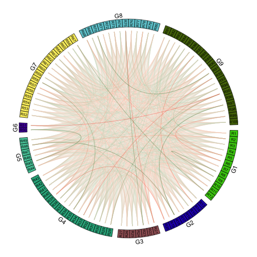

```r
circos.clear()
```

You can see the colors for weak correltion is deeper than the first circular plot, this is because in the second one, all links come from the middle of each entity which increases the overlapping of links, and that is why we draw the highest correlation last.

Basically the second circular plot is similar as the first circular one, but it is good at visualizing even larger matrix.